# Homework 11

Agnieszka Sitko

## Plots

The relation between `Reaction` and `Days` for each subject is plotted below.

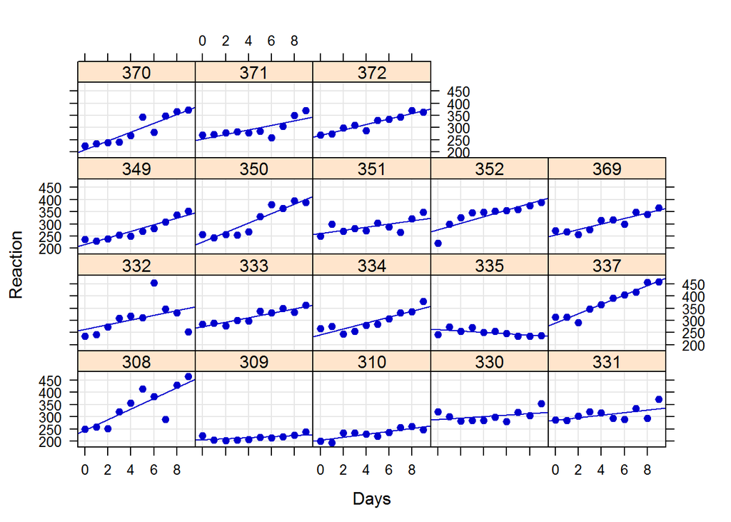

For each plot linear trendline is added. Most subjects tend to increase their reaction time with the increase in the number of days with restricted amount of sleep.

## Model

We will introduce a model which assumes that there is a linear and fixed relation between `Reaction` and `Days` in a population as a whole and there may exist random effect of `Subject`. The results of such a model are listed as follows.

```
## Linear mixed model fit by REML ['lmerMod']
## Formula: Reaction ~ Days + (Days | Subject)
##
## REML criterion at convergence: 1743.6
##
## Scaled residuals:
##     Min      1Q  Median      3Q     Max
## -3.9536 -0.4634  0.0231  0.4634  5.1793
##
## Random effects:
##  Groups   Name        Variance Std.Dev. Corr
##  Subject  (Intercept) 612.09   24.740
##           Days         35.07    5.922   0.07
##  Residual             654.94   25.592
## Number of obs: 180, groups:  Subject, 18
##
## Fixed effects:
##             Estimate Std. Error t value
## (Intercept)  251.405      6.825   36.84
## Days          10.467      1.546    6.77
##
## Correlation of Fixed Effects:
##      (Intr)
## Days -0.138
```

From this summary we can say that there exists positive relation between the number of days with sleep restriction and reaction time of a subject in a population.

It may be shown that the model is correct (all variables are important, random variables are normally distributed).

SIGNIFICANCE OF THE FIXED EFFECT

```r
2 * pnorm(6.77, lower.tail = FALSE)
```

```
## [1] 1.287824e-11
```

SIGNIFICANCE OF THE RANDOM EFFECT

```r
model1 <- lm(Reaction ~ Days)
anova(model, model1)[[8]][2]
```

```
## [1] 5.968819e-32
```

MODEL DIAGNOSTICS

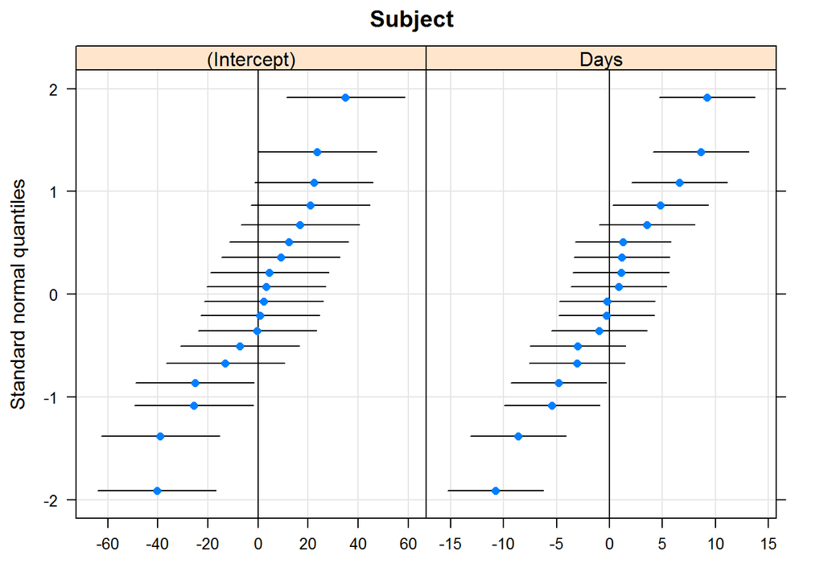

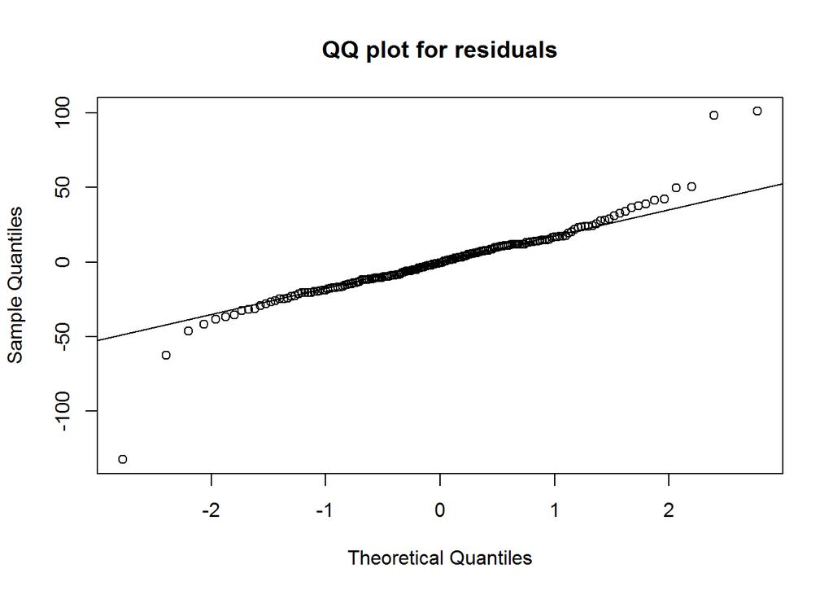

## Individual slopes

Main statistics of slopes calculated for the model may be find below.

```r
slopes <- ranEf$Subject[,2] + fixef(model)[2]
summary(slopes)
```

```
##    Min. 1st Qu.  Median    Mean 3rd Qu.    Max.
## -0.2849  7.4110 10.7900 10.4700 13.4400 19.6700
```

As expected most slopes are positive (only one is negative). So, even if we consider the random effect of subjects, the positive relation between `Reaction` and `Days` will be kept.